# Pantaleo Project - HIV- Patients -

Valentin Voillet

# Contents

*File creation: July, 18th 2017*  
*Update: July, 19th 2017*

# 1 Data Loading & Description

In this script, only **HIV- patients** (Live Cells) are analyzed.

Three patients are available **TFH041**, **TFH095** and **TFH146**. It is important to note that there has been a naming switch between Tfh and Live Cells for patient TFH041.

Before filtering according Sam’s thresholds (keep cells with more/equal than **750 UMIs** and **400 genes**), we observe that TF041 has a low number of good quality cells from PBMC sample - see figure below and script_070517_ExploratoryStudy_TFH041.html. The number of UMIs and detected genes seem quite close between patients (except TFH041), we might observe a technical effect after aggregation of those patients together.

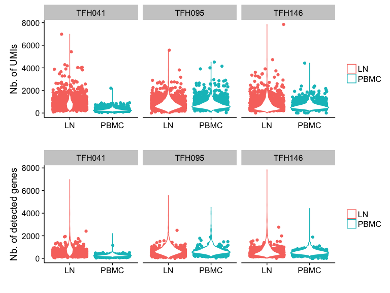

```r
###--- Filtering
##- TFH041
#- LN
TFH041_LN <- TFH041_LN[, which(apply(TFH041_LN, 2, function(x) sum(x != 0)) >= 400 & apply(TFH041_LN, 2, sum) >= 750)]
TFH041_LN <- TFH041_LN[which(apply(TFH041_LN, 1, sum) != 0), ] # 15,731 genes & 727 cells
#- PBMC
TFH041_PBMC <- TFH041_PBMC[, which(apply(TFH041_PBMC, 2, function(x) sum(x != 0)) >= 400 & apply(TFH041_PBMC, 2, sum) >= 750)]
TFH041_PBMC <- TFH041_PBMC[which(apply(TFH041_PBMC, 1, sum) != 0), ] # 3,345 genes & 12 cells
#- Merging
TFH041 <- rbind.fill(as.data.frame(t(TFH041_LN)), as.data.frame(t(TFH041_PBMC)))
rownames(TFH041) <- c(paste(colnames(TFH041_LN), 'LN', sep = '_'), paste(colnames(TFH041_PBMC), 'PBMC', sep = '_'))
dim(TFH041) # 739 cells & 15,731 genes
TFH041[is.na(TFH041)] <- 0
TFH041 <- as.data.frame(t(TFH041))

##- TFH095
#- LN
TFH095_LN <- TFH095_LN[, which(apply(TFH095_LN, 2, function(x) sum(x != 0)) >= 400 & apply(TFH095_LN, 2, sum) >= 750)]
TFH095_LN <- TFH095_LN[which(apply(TFH095_LN, 1, sum) != 0), ] # 15,466 genes & 558 cells
#- PBMC
TFH095_PBMC <- TFH095_PBMC[, which(apply(TFH095_PBMC, 2, function(x) sum(x != 0)) >= 400 & apply(TFH095_PBMC, 2, sum) >= 750)]
TFH095_PBMC <- TFH095_PBMC[which(apply(TFH095_PBMC, 1, sum) != 0), ] # 14,740 genes & 564 cells
#- Merging
TFH095 <- rbind.fill(as.data.frame(t(TFH095_LN)), as.data.frame(t(TFH095_PBMC)))
rownames(TFH095) <- c(paste(colnames(TFH095_LN), 'LN', sep = '_'), paste(colnames(TFH095_PBMC), 'PBMC', sep = '_'))
dim(TFH095) # 1,122 cells & 17,575 genes
TFH095[is.na(TFH095)] <- 0
TFH095 <- as.data.frame(t(TFH095))

##- TFH146
#- LN
TFH146_LN <- TFH146_LN[, which(apply(TFH146_LN, 2, function(x) sum(x != 0)) >= 400 & apply(TFH146_LN, 2, sum) >= 750)]
TFH146_LN <- TFH146_LN[which(apply(TFH146_LN, 1, sum) != 0), ] # 14,946 genes & 417 cells
#- PBMC
TFH146_PBMC <- TFH146_PBMC[, which(apply(TFH146_PBMC, 2, function(x) sum(x != 0)) >= 400 & apply(TFH146_PBMC, 2, sum) >= 750)]
TFH146_PBMC <- TFH146_PBMC[which(apply(TFH146_PBMC, 1, sum) != 0), ] # 12,391 genes & 409 cells
#- Merging
TFH146 <- rbind.fill(as.data.frame(t(TFH146_LN)), as.data.frame(t(TFH146_PBMC)))
rownames(TFH146) <- c(paste(colnames(TFH146_LN), 'LN', sep = '_'), paste(colnames(TFH146_PBMC), 'PBMC', sep = '_'))
dim(TFH146) # 826 cells & 16,230 genes
TFH146[is.na(TFH146)] <- 0
TFH146 <- as.data.frame(t(TFH146))
```

After filtering according Sam’s thresholds (keep cells with more/equal than **750 UMIs** and **400 genes** - R code above), we have

- TFH041 - **739 cells** & **15,731 genes**
  - **727 cells** & **15,731 genes** - LN sample
  - **12 cells** & **3,345 genes** - PBMC sample
- TFH095 - **1,122 cells** & **17,575 genes**
  - **558 cells** & **15,466 genes** - LN sample
  - **564 cells** & **14,740 genes** - PBMC sample
- TFH146 - **826 cells** & **16,230 genes**
  - **417 cells** & **14,946 genes** - LN sample
  - **409 cells** & **12,391 genes** - PBMC sample

# 2 Seurat Analysis

As in Gierahn et al. (2017), library-size normalization is performed for each cell. UMI-collapsed gene expression values for each cell barcode were scaled by the total number of transcripts and multiplied by 10,000. Scaled expression data were then natural-log transformed before analysis using Seurat.

```r
###--- Merging
data_HIVneg <- rbind.fill(as.data.frame(t(TFH041)), as.data.frame(t(TFH095)), as.data.frame(t(TFH146)))
rownames(data_HIVneg) <- c(paste(colnames(TFH041), 'TFH041', sep = '_'), paste(colnames(TFH095), 'TFH095', sep = '_'), paste(colnames(TFH146), 'TFH146', sep = '_'))
dim(data_HIVneg) # 2,687 cells & 21,224 genes
data_HIVneg[is.na(data_HIVneg)] <- 0
data_HIVneg <- as.data.frame(t(data_HIVneg))

###--- Normalization
#- Seurat object - log2-transformation & library-size normalization - done on Rhino - why? issue with R 3.4.0
seuratObj <- new('seurat', raw.data = data_HIVneg)
seuratObj <- Setup(seuratObj, min.cells = 0, min.genes = 0, project = 'Pantaleo', total.expr = 10000) # filtering already done - see above
#- Output
saveRDS(seuratObj, file = 'Output_071817/HIVnegativePatients.rds')
seuratObj <- readRDS('Output_071817/HIVnegativePatients.rds') # 2,687 cells & 21,224 genes
```

```r
###--- Regress out unwanted sources of variation
mito.genes <- grep("^MT-", rownames(seuratObj@data), value = TRUE)
percent.mito <- colSums(as.matrix(expm1(seuratObj@data[mito.genes, ]))) / colSums(as.matrix(expm1(seuratObj@data)))

batch <- sapply(str_split(colnames(seuratObj@data), '_'), function(x) paste(x[2], x[3], sep = '_'))
batch <- as.factor(batch)
seuratObj <- AddMetaData(seuratObj, percent.mito, 'percent.mito')

seuratObj <- AddMetaData(seuratObj, batch, 'batch')
GenePlot(seuratObj, 'nUMI', 'percent.mito')
GenePlot(seuratObj, 'nUMI', 'nGene') # 0.94
#- remove unwanted sources of variation
seuratObj <- RegressOut(seuratObj, latent.vars = c('nUMI', 'percent.mito', 'batch')) # remove effect of CDR (high correlation between nGene and nUMI - 0.94) and mitochondrial effect
```

Seurat calculates highly variable genes and focuses on these for downstream analysis.

```r
###--- Detection of variable genes across the single cells
seuratObj <- MeanVarPlot(seuratObj, fxn.x = expMean, fxn.y = logVarDivMean, x.low.cutoff = 0.25, x.high.cutoff = 3, y.cutoff = 0.5, do.contour = FALSE)
length(seuratObj@var.genes) # 743 highly variable genes
```

We identify 743 highly variable genes with log-mean expression values greater than 0.25 and dispersion (variance/mean) greater than 0.5.

```r
###--- PCA
#- PCA performed on the scaled data and using only highly variable genes
seuratObj <- PCA(seuratObj, pc.genes = seuratObj@var.genes)
seuratObj <- ProjectPCA(seuratObj)
```

We can identify markers that are strongly correlated with cellular heterogeneity - see below. We can observe some known cell markers (ILR7, NKG7 and GZMA).

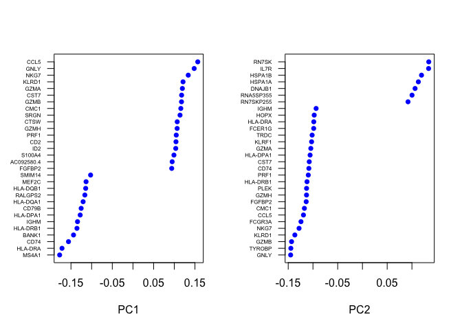

One thousand iterations of the t-SNE algorithm (Barnes-hut implementation) using a perplexity value of 40 and the first top 8 principal components is performed. Those first top 8 PCs were chosen according to the standard deviation - see below.

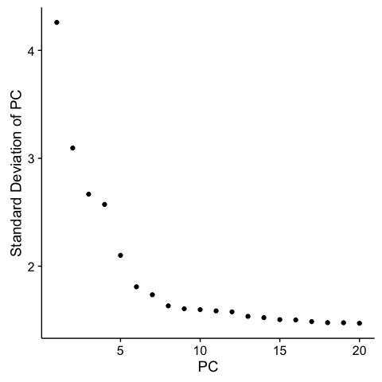

```r
###--- tSNE
seuratObj <- RunTSNE(seuratObj, dims.use = 1:8, perplexity = 40, do.fast = TRUE)
```

Let’s look at the tSNE plots now - perplexity of 40 and 1,000 iterations of the Barnes-Hut implementation.

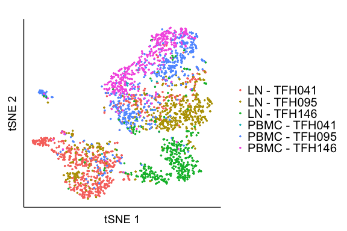

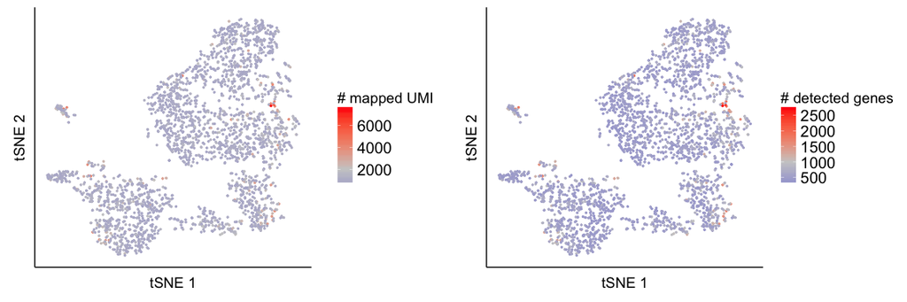

A batch/patient effect is easily observed here. Patient TFH146 - LN seems to be different than the two others. This patient has been analyzed/sequenced in June, while TFH041 and TFH095 have been analyzed/sequenced in July.

Let’s look at some cell markers.

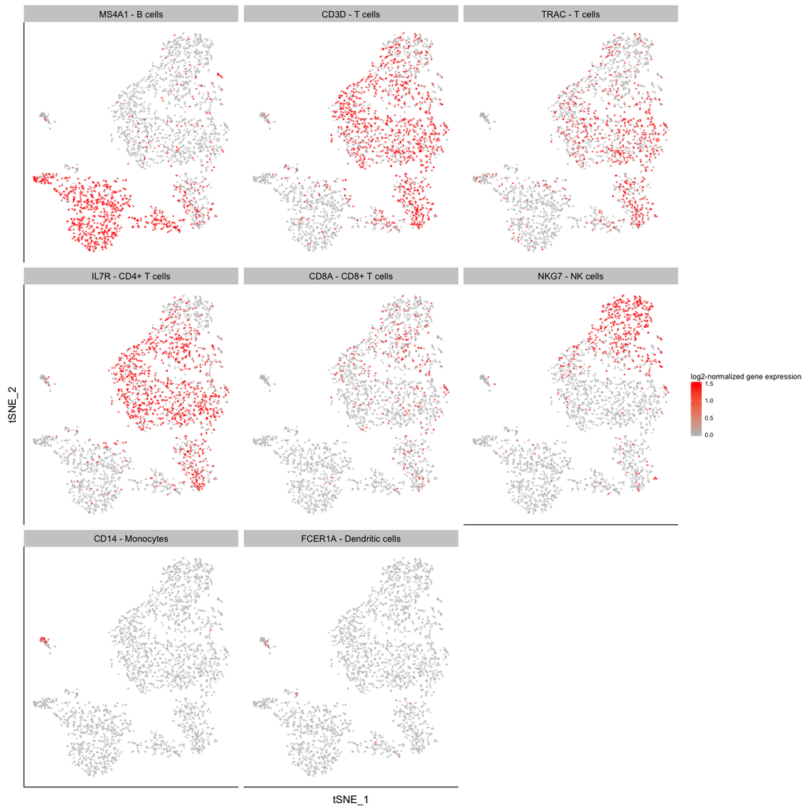

We confirm that TFH146 - PBMC has a really low number of B cells. Of course, we observe T cells (CD4 and CD8), NK cells and Monocytes.

It doesn’t look so bad - from PBMC we are able to see expression of T cells, NK cells, Monocytes and sometimes B cells; from LN we are able to observe T cells, B cells, NK cells and Monocytes.